# 多變量 Gaussian Mixture Model 與 GMM Skill

從統計理論、Hair 六階段流程到可重現的 Claude Code Skill

**警告文件狀態：初版，尚未學術定稿**

功能驗收已完成，學術內容審查的修訂已納入，但仍有待核對項目（§ 24）。修訂紀錄見 `tutorial/REVISION_LOG.md`。

# Part I — 專題動機與概覽

# 1 這份教材要解決什麼問題

統計軟體可以很快算出一個 Gaussian Mixture Model (GMM)，但分析者真正需要回答的問題往往不是「程式跑完了沒」：

- 資料適合用 GMM 嗎？缺失值該怎麼處理，由誰決定？
- EM 收斂了，代表找到最好的解嗎？
- BIC 選出 $G=5$，而 5 正好是搜尋上界，這個結論有多可靠？
- 模型分出的成分，是真實存在的群體嗎？

本專案把這些判斷做成一個 **Claude Code Skill**（`multivariate-gmm`）。它參考 Hair 等 (2019年) 第 4 章的六階段分群架構（pp. 199–229），並針對 GMM 加以延伸。各階段的內容不完全等同於原書，差異見 § 12。它用 base R 實作 full-covariance GMM 的 EM，並要求每一個會改變分析的決定都經過使用者確認。

**重要三個貫穿全文的原則**

1. **數字只來自程式**：Claude 不估計、不心算；本文的案例表格與主要結果也是渲染時從保存的檔案讀取。
2. **改變分析的決定屬於使用者**：刪列、插補、標準化、切換模型都要明確核准。
3. **不宣稱沒做到的事**：Gaussian 成分不一定是自然群組，posterior 不等於分類準確率，收斂不等於全域最佳。

## 1.1 三種讀法

| 讀者 | 建議路徑 |
| --- | --- |
| 課堂展示 | § 1.2 → 各理論章的圖 → § 13 → § 19、§ 20 |
| 統計理論學習 | Part II 全部，並展開「推導」區塊 |
| 想使用或開發 Skill | Part III 全部 → § 21 → § 25 |

## 1.2 全文地圖

```
flowchart LR
  A["Part I<br/>動機與概覽"] --> B["Part II<br/>多變量統計知識"]
  B --> C["Part III<br/>Skill 設計與實作"]
  C --> D["Part IV<br/>真實資料與示範"]
  D --> E["Part V<br/>限制與來源"]
```

## 1.3 如何判讀本文的結果：證據層級

本文引用的結果不屬於同一種地位。每一份結果都會標示下列層級，並列出來源路徑、設定與適用範圍。

| 層級 | 意義 | 可否當作分析結論 |
| --- | --- | --- |
| 已核准正式結果 | 使用者逐階段核准的結果 | 可以，但仍受其限制 |
| 已核准工作模型 | 使用者核准作為後續解釋的敏感度模型，**不取代**正式 Stage 4 模型 | 僅在其核准範圍內 |
| 診斷資料 | 收斂確認、KNN 稽核等，只提供檢查資訊 | 不能單獨改變模型 |
| mclust 驗證對照 | 用獨立實作比較數值，mclust 不參與正式估計 | 不能 |
| 未採用的暫存區試算 | F9 初始化試算，未核准、未登記為 Candidate | 不能 |
| 教學示範 | example data 上的模擬核准 | 不能 |
| 教學模擬 | 本文為解說而模擬的小資料 | 不能 |

# Part II — Multivariate Statistical Knowledge

本部分的符號與 Skill 一致：$n$ 為列數，$p$ 為變數數，$G$ 為成分數，$x_j\in\mathbb{R}^p$ 為第 $j$ 列，$\pi_i,\mu_i,\Sigma_i$ 為第 $i$ 個成分的混合比例、平均與共變異數。每一節最後列出對應的 R 函式；完整對照見 § 25。

# 2 Multivariate Normal Distribution

## 2.1 密度函數

若 $X\sim N_p(\mu,\Sigma)$，其中 $\Sigma$ 為對稱正定矩陣，則

$$\phi_p(x;\mu,\Sigma)=(2\pi)^{-p/2}|\Sigma|^{-1/2}\exp\!\left\{-\tfrac12 (x-\mu)^\top\Sigma^{-1}(x-\mu)\right\}.
\qquad(1)$$

取對數後，

$$\log\phi_p(x;\mu,\Sigma)=-\tfrac p2\log(2\pi)-\tfrac12\log|\Sigma|-\tfrac12 (x-\mu)^\top\Sigma^{-1}(x-\mu).
\qquad(2)$$

幾個在 GMM 中會直接用到的性質：

- **Affine 變換**：若 $Y=AX+b$ 且 $A$ 可逆，則 $Y\sim N_p(A\mu+b,\,A\Sigma A^\top)$。
- **邊際與條件分布**：將 $X$ 分塊為 $(X_1,X_2)$，則 $X_1\sim N(\mu_1,\Sigma_{11})$，且

$$X_1\mid X_2=x_2\sim N\!\left(\mu_1+\Sigma_{12}\Sigma_{22}^{-1}(x_2-\mu_2),\ \Sigma_{11}-\Sigma_{12}\Sigma_{22}^{-1}\Sigma_{21}\right).
\qquad(3)$$

條件平均是 $x_2$ 的線性函數，這正是以其他變數填補缺失值的理論來源；但 Skill 的 KNN 並不使用這個公式（§ 11）。

## 2.2 Mahalanobis distance

$$D^2(x)=(x-\mu)^\top\Sigma^{-1}(x-\mu).
\qquad(4)$$

$D^2$ 同時考慮變異數與相關性。令 $\Sigma=V\Lambda V^\top$，則 $D^2=\sum_{k}\big(v_k^\top(x-\mu)\big)^2/\lambda_k$，因此等高線 $D^2=c$ 是以特徵向量為軸、半軸長 $\sqrt{c\lambda_k}$ 的橢球。若 $X\sim N_p(\mu,\Sigma)$ 且 $\mu,\Sigma$ 為**已知**，則 $D^2\sim\chi^2_p$。以樣本平均與樣本共變異代入時，這只是 $n$ 遠大於 $p$ 時的近似。

**顯示程式碼**

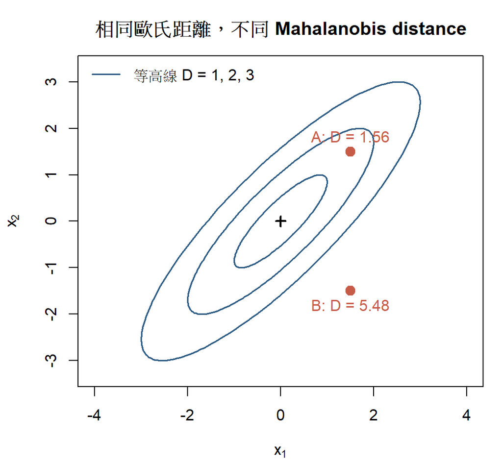

圖 1: 相關性為 0.85 時，兩點與中心的歐氏距離相同，但 Mahalanobis distance 差距很大。（教學模擬）

```r
fig_mahalanobis()
```

**註釋Skill 中的對應**

`em_logdens()` 計算 式 2。Stage 3 的 S3-07 以**樣本**相關矩陣計算全體資料的 $D^2$，再與 $\chi^2_{p,0.999}$ 比較，所以卡方門檻只是近似。它也只是 screening：資料若來自混合分布，全體 $D^2$ 本來就不服從 $\chi^2_p$，因此不會自動刪列。

# 3 Covariance Matrix、正定性與數值條件

## 3.1 共變異數矩陣

$\Sigma=\mathrm{E}[(X-\mu)(X-\mu)^\top]$ 必為對稱半正定。要讓 式 1 存在，需要 $\Sigma$ **正定**，也就是對所有非零 $a$，$a^\top\Sigma a>0$，等價於所有特徵值 $\lambda_k>0$。

| 概念 | 定義 | 在 GMM 中的意義 |
| --- | --- | --- |
| 特徵值 | $\Sigma v_k=\lambda_k v_k$ | 主軸方向的變異量；$\lambda_{\min}\to0$ 代表分布壓扁 |
| 行列式 | $\lvert\Sigma\rvert=\prod_k\lambda_k$ | 橢球體積；趨近 0 時密度可以無限大 |
| 條件數 | $\kappa(\Sigma)=\lambda_{\max}/\lambda_{\min}$ | 不同方向上的相對尺度差異；反映相對接近奇異的程度，不反映等比例縮小 |
| Cholesky | $\Sigma=R^\top R$，$R$ 上三角 | 精確運算下，對稱矩陣有此分解若且唯若正定；實際計算見下節 |

## 3.2 穩定的數值計算

若 $\Sigma_i=R_i^\top R_i$，則

$$\log|\Sigma_i|=2\sum_{k}\log R_{i,kk},\qquad (x-\mu_i)^\top\Sigma_i^{-1}(x-\mu_i)=\big\|R_i^{-\top}(x-\mu_i)\big\|^2 .
\qquad(5)$$

只需解三角系統，不必求反矩陣。在精確運算下，正定矩陣必有 Cholesky decomposition；但在有限精度計算中，分解成功或失敗仍可能受浮點誤差、矩陣尺度及數值條件影響，所以「`chol()` 成功」與「矩陣在數學上正定」不完全等價。各列的 log-likelihood 再用 log-sum-exp 避免 underflow：

$$a_{ji}=\log\pi_i+\log\phi_p(x_j;\mu_i,\Sigma_i),\quad m_j=\max_i a_{ji},\quad \ell_j=m_j+\log\sum_i \exp(a_{ji}-m_j).
\qquad(6)$$

**提示Skill 實際程式：em_logdens 與 em_estep**

```r
em_logdens <- function(X, mu, Sigma) {
  R <- tryCatch(chol(Sigma), error = function(e) NULL)
  if (is.null(R)) return(NULL)
  p <- ncol(X)
  z <- backsolve(R, t(X) - mu, transpose = TRUE) # R^{-T}(x - mu), p x n
  -0.5 * p * log(2 * pi) - sum(log(diag(R))) - 0.5 * colSums(z^2)
}
```

```r
em_estep <- function(X, par) {
  G <- length(par$pi); n <- nrow(X)
  a <- matrix(NA_real_, n, G)
  for (i in seq_len(G)) {
    ld <- em_logdens(X, par$mu[i, ], par$Sigma[[i]])
    if (is.null(ld)) return(list(ok = FALSE, reason = sprintf('covariance %d not positive definite in E-step', i)))
    a[, i] <- log(par$pi[i]) + ld
  }
  m <- apply(a, 1, max)
  lse <- m + log(rowSums(exp(a - m)))
  if (any(!is.finite(lse))) return(list(ok = FALSE, reason = 'non-finite log-likelihood contribution'))
  list(ok = TRUE, tau = exp(a - lse), loglik = sum(lse), row_loglik = lse)
}
```

## 3.3 共線性與尺度

**完全共線**時 rank 小於 $p$，任何成分的 $\Sigma_i$ 都是奇異的，full-covariance 密度沒有定義，因此 Stage 3 的 S3-03、S3-04 是 STOP。**近似共線**則只造成數值不穩，不是刪變數的理由，Stage 3 以 condition index、VIF、$|r|$ 給 WARNING（門檻為待審 heuristic，見 § 22）。

$$\mathrm{VIF}_k=\frac{1}{1-\rho_k^2},\qquad \text{condition index}=\sqrt{\lambda_{\max}(C)/\lambda_{\min}(C)}.
\qquad(7)$$

其中 $C$ 為相關矩陣，$\rho_k^2$ 是第 $k$ 個變數對其他變數迴歸的決定係數。程式以 `diag(solve(C))` 計算 VIF。

**尺度不變性。** 令 $z=A x+b$，$A$ 可逆。密度變換為 $f_Z(z)=f_X(x)/|\det A|$。Full-covariance GMM 的參數空間在可逆 affine 變換下封閉：$(\pi_i,\mu_i,\Sigma_i)$ 對應到 $(\pi_i,\,A\mu_i+b,\,A\Sigma_iA^\top)$。在對應的參數下，log-likelihood 僅相差一個與參數無關的常數，posterior responsibilities 保持不變；非退化的局部極值，以及適當條件下的駐點，也彼此對應：

$$\ell_z(\hat\theta_z)=\ell_x(\hat\theta_x)-n\log|\det A|\ \Longrightarrow\ \ell_x=\ell_z-n\sum_{k=1}^p\log s_k\quad(\text{z-score 時 }A=\mathrm{diag}(1/s_k)).
\qquad(8)$$

式中 $\hat\theta_x,\hat\theta_z$ 指任一組如此對應的參數。這**不表示**全域最大概似解存在：$G\ge2$ 的未受約束 GMM，likelihood 一般無上界（§ 5.1）。

Penguins 的已核准結果可以驗證這一點：z-score 尺度的 $\ell=$ -1,146.435，原始單位 $\ell=$ -5,150.688；由 式 8 計算得 -5,150.688。在**精確數學模型**下（把 z-score 的平均與標準差視為固定常數，且不考慮 guard），尺度不改變模型。但數學上的不變性，不等於距離型初始化及數值 guard 的實際執行結果不變：$\kappa\le10^{10}$ 的 guard 不是尺度不變量，k-means 與 Ward 的距離也依賴尺度，所以不同尺度可能得到不同的起點路徑或觸發不同的 guard。z-score 的好處是改善條件數（Penguins 由 $2.75\times10^5$ 降至 $25.4$，見 Stage 3 S3-09）並讓 k-means 初始化不受單位影響。

**註釋Skill 中的對應**

`em_check()` 執行 Cholesky 與條件數檢查；`em_cov_conditions()`、`em_cov_min_eigen()` 回報條件數與最小特徵值；`feasibility_stage3.R` 執行 S3-03 至 S3-09。

# 4 Finite Gaussian Mixture Model

## 4.1 定義

令潛在變數 $Z_j\in\{1,\dots,G\}$，$P(Z_j=i)=\pi_i$，且 $X_j\mid Z_j=i\sim N_p(\mu_i,\Sigma_i)$。積分掉 $Z_j$ 得到

$$f(x;\theta)=\sum_{i=1}^{G}\pi_i\,\phi_p(x;\mu_i,\Sigma_i),\qquad \pi_i>0,\ \sum_i\pi_i=1.
\qquad(9)$$

**顯示程式碼**

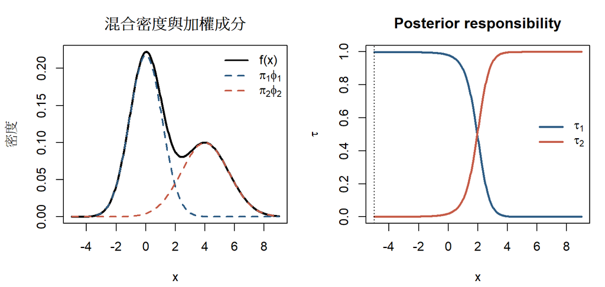

圖 2: 左：兩個加權成分相加成為混合密度。右：posterior responsibility 隨 x 平滑變化。（教學模擬）

```r
fig_mixture()
```

## 4.2 模型假設

| 假設 | 內容 | Skill 如何處理 |
| --- | --- | --- |
| 觀測獨立 | 概似是各列密度的乘積 | **無法由資料證明**；S3-14 要求使用者確認或記為 working assumption |
| 成分為 Gaussian | 只要求**每個成分**常態，不要求全體常態 | S3-10 不做全體常態檢定；偏態可能被多餘成分吸收 |
| 共變異結構 | Skill v1 固定為 component-specific full covariance（mclust 的 VVV） | S3-12；其他結構**未實作** |
| $G$ 有限且已知 | 在候選集合內比較 | Stage 3 核准候選，預設 1 到 5 只是起點 |
| 資料完整且連續 | 概似以完整連續向量定義 | Stage 2 處理缺失；Inf 為 BLOCKED |

## 4.3 參數個數

$(G-1)$ 個自由的混合比例、$Gp$ 個平均、每個對稱矩陣 $p(p+1)/2$ 個元素，因此

$$k_G=(G-1)+Gp+\frac{G\,p(p+1)}{2}.
\qquad(10)$$

$p=4$ 時每增加一個成分就多 15 個參數，$G=5$ 時 $k_G=74$。參數個數本身不保證可估計：Stage 3 將 $k_G\ge n$ 或 $n/G<p+1$ 視為 STOP，$n/G<5\,(p+p(p+1)/2)$ 只給 WARNING（待審 heuristic）。

## 4.4 Label switching

對任一排列 $\sigma$，把成分編號換成 $\sigma(1),\dots,\sigma(G)$ 不改變 式 9，所以同一個解有 $G!$ 個等價表示。這造成兩個實務問題：不同起點的同一個成分可能編號不同；比較參數前必須先對齊。

**註釋Skill 中的對應**

`em_reorder()` 把報告順序固定為混合比例遞減；`s4_align()` 在跨起點比較時搜尋使平均向量距離最小的排列；ARI、NMI 本身不受編號影響（§ 10）。

# 5 Likelihood：觀測資料與完整資料

**Observed-data log-likelihood**：

$$\ell(\theta)=\sum_{j=1}^n\log\sum_{i=1}^G\pi_i\,\phi_p(x_j;\mu_i,\Sigma_i).
\qquad(11)$$

對數裡有加總，所以沒有封閉解。若知道成分指標 $z_{ji}=\mathbb{1}(Z_j=i)$，**complete-data log-likelihood** 為

$$\ell_c(\theta)=\sum_{j=1}^n\sum_{i=1}^G z_{ji}\left\{\log\pi_i+\log\phi_p(x_j;\mu_i,\Sigma_i)\right\}.
\qquad(12)$$

此時每個成分各自是一個 Gaussian MLE，可以直接求解。EM 的想法就是用 式 12 的條件期望代替未知的 $z_{ji}$。

## 5.1 Likelihood 無上界

當 $G\ge2$ 時，$\ell(\theta)$ 沒有全域最大值。令 $\mu_1=x_1$、$\Sigma_1=\sigma^2 I$，並固定 $\pi_1,\pi_2>0$ 與正定的 $\Sigma_2$。第一列至少貢獻 $\pi_1(2\pi\sigma^2)^{-p/2}$；其他列至少貢獻 $\pi_2\phi_p(x_j;\mu_2,\Sigma_2)>0$，這個下界與 $\sigma$ 無關。因此

$$\ell(\theta)\ \ge\ \log\!\big[\pi_1(2\pi\sigma^2)^{-p/2}\big]+\sum_{j\ne1}\log\!\big[\pi_2\,\phi_p(x_j;\mu_2,\Sigma_2)\big]\xrightarrow[\sigma\to0]{}\infty .
\qquad(13)$$

關鍵是其他列的貢獻有**正的下界**，而不只是有上界。$G=1$ 且樣本共變異正定時不會發生這種情形。這稱為 **covariance collapse**。因此未受約束 GMM 的 likelihood 可能無上界，一般不存在全域最大概似解。實務上通常搜尋非退化的局部最適解或數值上可接受的擬合解。EM 不保證全域最佳；通過停止規則的結果也不應直接稱為已證明的局部最大概似解，`CONVERGED_VALID` 不等於已證明達到局部最大值（見 §6.6）。**likelihood 較高不代表模型較好**。

**顯示程式碼**

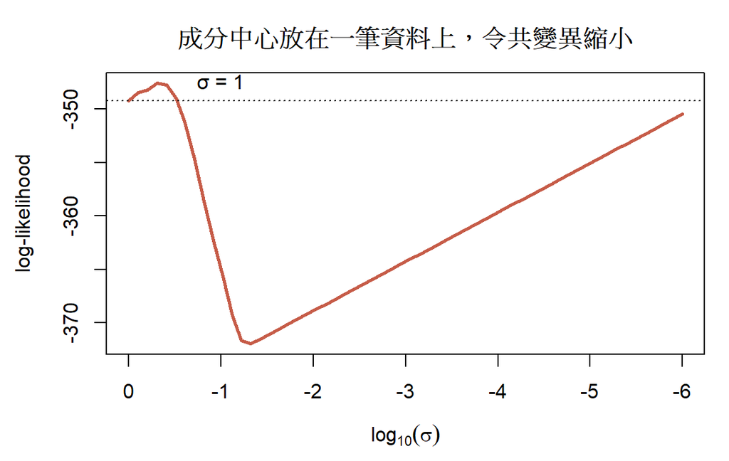

```r
fig_collapse(SK)
```

# 6 EM Algorithm

EM 的一般架構來自 Dempster 等 (1977年)。本章的推導專指 Skill 使用的 full-covariance Gaussian mixture。

## 6.1 為什麼 EM 可行：下界分解

對任意分布 $q_j(i)$，由 Jensen 不等式，

$$\log f(x_j;\theta)=\log\sum_i q_j(i)\frac{\pi_i\phi_{ji}}{q_j(i)}\ \ge\ \sum_i q_j(i)\log\frac{\pi_i\phi_{ji}}{q_j(i)},
\qquad(14)$$

其中 $\phi_{ji}=\phi_p(x_j;\mu_i,\Sigma_i)$。更精確地，

$$\ell(\theta)=\underbrace{\sum_{j,i} q_j(i)\log\frac{\pi_i\phi_{ji}}{q_j(i)}}_{\mathcal{L}(q,\theta)}+\underbrace{\sum_j \mathrm{KL}\big(q_j\,\|\,p(Z_j\mid x_j;\theta)\big)}_{\ge0}.
\qquad(15)$$

取 $q_j$ 等於後驗時 KL 為 0，下界碰到 $\ell(\theta)$。這就是 E-step。

## 6.2 E-step 與 Q-function

在 $\theta^{(t)}$ 下由 Bayes 定理，

$$\tau_{ji}^{(t)}=P(Z_j=i\mid x_j;\theta^{(t)})=\frac{\pi_i^{(t)}\phi_p(x_j;\mu_i^{(t)},\Sigma_i^{(t)})}{\sum_{h}\pi_h^{(t)}\phi_p(x_j;\mu_h^{(t)},\Sigma_h^{(t)})}=\exp(a_{ji}-\ell_j).
\qquad(16)$$

$\ell_c$ 對 $z_{ji}$ 是線性的，所以條件期望只需把 $z_{ji}$ 換成 $\tau_{ji}$：

$$Q(\theta\mid\theta^{(t)})=\sum_{j=1}^n\sum_{i=1}^G\tau_{ji}^{(t)}\left\{\log\pi_i+\log\phi_p(x_j;\mu_i,\Sigma_i)\right\}.
\qquad(17)$$

**Q 與下界的關係。** 取 $q_j=\tau_j^{(t)}$ 代入 式 15 的下界，得到

$$\mathcal{L}(\tau^{(t)},\theta)=Q(\theta\mid\theta^{(t)})-\sum_{j,i}\tau_{ji}^{(t)}\log\tau_{ji}^{(t)} .
\qquad(18)$$

最後一項不含 $\theta$，所以最大化 $Q$ 就是最大化下界。